# Predicciones de salidas de colaboradores de RiotGames (Caso Hipotetico)

# HR Employee Attrition Predicton on RiotGames Company (Hypothetical Case)

# Contexto/Context

**ESPAÑOL**

Riot Games es una multinacional con miles de colaboradores repartidos por todo el mundo. La empresa anehela la contratación de los mejores talentos disponibles y en retenerlos el mayor tiempo posible. Por lo cual, se invierte una gran cantidad de recurso (y dinero) en retener a los empleados existentes a traves de diversas iniciativas. Sin embargo, la organización (gerente de operaciones) quiere reducir los costos de retener empleados. Para ello, nos proponenn limitar los incentivos unicamente a los empleados que corren riesgo de abandono.

Se le otorgo el desafío a la area de people de identificar patrones y caracteristicas de los empleados que abandonan la organización. Ademas, deben de utilizar la información levantada para predecir si un empleado esta en riesgo de abandono.

**ENGLISH**

Riot Games is a multinational company with thousands of employees around the world. The company strives to recruit the best talent available and to retain them for as long as possible. Therefore, a great deal of resources (and money) is invested in retaining existing employees through various initiatives. However, the organization (operations manager) wants to reduce the costs of retaining employees. To do so, we propose to limit incentives to only those employees who are at risk of leaving.

The people area was given the challenge of identifying patterns and characteristics of employees who leave the organization. In addition, they must use the information gathered to predict whether an employee is at risk of leaving.

# Objetivo/Objective

**ESPAÑOL**

1. Identificar las distintas variables o factores que hacen a los colaboradores renunciar.
2. Construir un modelo que sea capaz de predecir si un colaborador va a renunciar o no.

**ENGLISH**

1. To identify the different factors that drive attrittion in riot games employees.
2. To build a model to predict if an employee wil attrite or not.

# Let´s goooo

```python
import pandas as pd
import numpy as np
import matplotlib.pyplot as plt
import seaborn as sns

#Para crecer los datos usando puntaje Z
from sklearn.preprocessing import StandardScaler
from sklearn.model_selection import train_test_split

#Algortimos que hay que utilizar
from sklearn.discriminant_analysis import LinearDiscriminantAnalysis
from sklearn.discriminant_analysis import QuadraticDiscriminantAnalysis
from sklearn.linear_model import LogisticRegression
from sklearn.neighbors import KNeighborsClassifier

#Metricas para evluar el modelo
from sklearn.metrics import confusion_matrix, classification_report, precision_recall_curve

#Para afinar el modelo
from sklearn.model_selection import GridSearchCV

#Para ignorar las warnings
import warnings
warnings.filterwarnings("ignore")
```

# Aqui agregamos la Data / Load the data

Debes subir tu excell con la base de datos que recolectaste de tu propia organización. En este caso utilizaremos una base ficticia de Riot Games.

```python
df = pd.read_excel(r'C:\Users\marti\OneDrive\Escritorio\Importante\Data Science -MIT\HR_RiotGames_Employee_Attrition_Dataset.xlsx')
```

```python
df.head(10)
```

|  | EmployeeNumber | Attrition | Age | BusinessTravel | DailyRate | Department | DistanceFromHome | Education | EducationField | EnvironmentSatisfaction | ... | StandardHours | StockOptionLevel | TotalWorkingYears | TrainingTimesLastYear | WorkLifeBalance | YearsAtCompany | YearsInCurrentRole | YearsSinceLastPromotion | YearsWithCurrManager | Gamers |
| --- | --- | --- | --- | --- | --- | --- | --- | --- | --- | --- | --- | --- | --- | --- | --- | --- | --- | --- | --- | --- | --- |
| 0 | 1 | Yes | 41 | Travel_Rarely | 1102 | Business Department | 1 | 2 | Programming | 2 | ... | 80 | 0 | 8 | 0 | 1 | 6 | 4 | 0 | 5 | Yes |
| 1 | 2 | No | 49 | Travel_Frequently | 279 | Technology Department | 8 | 1 | Programming | 3 | ... | 80 | 1 | 10 | 3 | 3 | 10 | 7 | 1 | 7 | Yes |
| 2 | 3 | Yes | 37 | Travel_Rarely | 1373 | Technology Department | 2 | 2 | Other | 4 | ... | 80 | 0 | 7 | 3 | 3 | 0 | 0 | 0 | 0 | Yes |
| 3 | 4 | No | 33 | Travel_Frequently | 1392 | Technology Department | 3 | 4 | Programming | 4 | ... | 80 | 0 | 8 | 3 | 3 | 8 | 7 | 3 | 0 | Yes |
| 4 | 5 | No | 27 | Travel_Rarely | 591 | Technology Department | 2 | 1 | Business | 1 | ... | 80 | 1 | 6 | 3 | 3 | 2 | 2 | 2 | 2 | Yes |
| 5 | 6 | No | 32 | Travel_Frequently | 1005 | Technology Department | 2 | 2 | Programming | 4 | ... | 80 | 0 | 8 | 2 | 2 | 7 | 7 | 3 | 6 | Yes |
| 6 | 7 | No | 59 | Travel_Rarely | 1324 | Technology Department | 3 | 3 | Business | 3 | ... | 80 | 3 | 12 | 3 | 2 | 1 | 0 | 0 | 0 | No |
| 7 | 8 | No | 30 | Travel_Rarely | 1358 | Technology Department | 24 | 1 | Programming | 4 | ... | 80 | 1 | 1 | 2 | 3 | 1 | 0 | 0 | 0 | No |
| 8 | 9 | No | 38 | Travel_Frequently | 216 | Technology Department | 23 | 3 | Programming | 4 | ... | 80 | 0 | 10 | 2 | 3 | 9 | 7 | 1 | 8 | Yes |
| 9 | 10 | No | 36 | Travel_Rarely | 1299 | Technology Department | 27 | 3 | Business | 3 | ... | 80 | 2 | 17 | 3 | 2 | 7 | 7 | 7 | 7 | No |

10 rows × 35 columns

```python
df.info()
```

```
<class 'pandas.core.frame.DataFrame'>
RangeIndex: 2940 entries, 0 to 2939
Data columns (total 35 columns):
 #   Column                    Non-Null Count  Dtype
---  ------                    --------------  -----
 0   EmployeeNumber            2940 non-null   int64
 1   Attrition                 2940 non-null   object
 2   Age                       2940 non-null   int64
 3   BusinessTravel            2940 non-null   object
 4   DailyRate                 2940 non-null   int64
 5   Department                2940 non-null   object
 6   DistanceFromHome          2940 non-null   int64
 7   Education                 2940 non-null   int64
 8   EducationField            2940 non-null   object
 9   EnvironmentSatisfaction   2940 non-null   int64
```

[output cut: 27 more lines]

**¿Que vemos?** Nos permite saber que cosas son Int64 (numeros) y que cosas son Object (letras)

```python
df.nunique ()
```

```
EmployeeNumber              2940
Attrition                      2
Age                           43
BusinessTravel                 3
DailyRate                    886
Department                     3
DistanceFromHome              29
Education                      5
EducationField                 6
EnvironmentSatisfaction        4
Gender                         2
HourlyRate                    71
JobInvolvement                 4
JobLevel                       5
JobRole                        9
JobSatisfaction                4
MaritalStatus                  3
MonthlyIncome               1349
MonthlyRate                 1427
NumCompaniesWorked            10
Over18                         1
OverTime                       2
PercentSalaryHike             15
PerformanceRating              2
RelationshipSatisfaction       4
StandardHours                  1
StockOptionLevel               4
TotalWorkingYears             40
TrainingTimesLastYear          7
WorkLifeBalance                4
YearsAtCompany                37
YearsInCurrentRole            19
YearsSinceLastPromotion       16
YearsWithCurrManager          18
Gamers                         2
dtype: int64
```

**¿Que vemos?** Aqui se muestran el numero de "opciones" que tiene cada una de las categorias.

1. Employee Number es el codigo de cada colaborador, es algo unico. Asi que esta columna no nos va a gregar ningun valor.
2. Las columnas de Over18 y StandarHours solo tienenn un valor, asi que estas columnas tambien no nos agregaran valor.
3. Con estos numeros podemos identificar cuales columnas son continuas y cuales son categoricas.

```python
#Columnas que seran eliminadas
df=df.drop(['EmployeeNumber','Over18','StandardHours'], axis=1)
```

```python
#Creando columnas numericas
```

```python
#Creando columnas numericas
num_cols=['DailyRate','Age','DistanceFromHome','MonthlyIncome','MonthlyRate','PercentSalaryHike','TotalWorkingYears','YearsAtCompany','NumCompaniesWorked','HourlyRate','YearsInCurrentRole','YearsSinceLastPromotion','YearsWithCurrManager','TrainingTimesLastYear']

#Creando columnas categoricas
cat_cols=['Attrition','OverTime','BusinessTravel','Department','Education','EducationField','JobSatisfaction','EnvironmentSatisfaction','WorkLifeBalance','StockOptionLevel','Gender','PerformanceRating','JobInvolvement','JobLevel','JobRole','MaritalStatus','RelationshipSatisfaction','Gamers']
```

# A explorar y analizar la data / Exploratory Data Analysis

**ANALISIS A LAS COLUMNAS NUMERICAS Y VER QUE SACAMOS DE AHÍ**

```python
#Resumen estadistico...
df[num_cols].describe().T
```

|  | count | mean | std | min | 25% | 50% | 75% | max |
| --- | --- | --- | --- | --- | --- | --- | --- | --- |
| DailyRate | 2940.0 | 802.485714 | 403.440447 | 102.0 | 465.0 | 802.0 | 1157.0 | 1499.0 |
| Age | 2940.0 | 36.923810 | 9.133819 | 18.0 | 30.0 | 36.0 | 43.0 | 60.0 |
| DistanceFromHome | 2940.0 | 9.192517 | 8.105485 | 1.0 | 2.0 | 7.0 | 14.0 | 29.0 |
| MonthlyIncome | 2940.0 | 6502.931293 | 4707.155770 | 1009.0 | 2911.0 | 4919.0 | 8380.0 | 19999.0 |
| MonthlyRate | 2940.0 | 14313.103401 | 7116.575021 | 2094.0 | 8045.0 | 14235.5 | 20462.0 | 26999.0 |
| PercentSalaryHike | 2940.0 | 15.209524 | 3.659315 | 11.0 | 12.0 | 14.0 | 18.0 | 25.0 |
| TotalWorkingYears | 2940.0 | 11.279592 | 7.779458 | 0.0 | 6.0 | 10.0 | 15.0 | 40.0 |
| YearsAtCompany | 2940.0 | 7.008163 | 6.125483 | 0.0 | 3.0 | 5.0 | 9.0 | 40.0 |
| NumCompaniesWorked | 2940.0 | 2.693197 | 2.497584 | 0.0 | 1.0 | 2.0 | 4.0 | 9.0 |
| HourlyRate | 2940.0 | 65.891156 | 20.325969 | 30.0 | 48.0 | 66.0 | 84.0 | 100.0 |
| YearsInCurrentRole | 2940.0 | 4.229252 | 3.622521 | 0.0 | 2.0 | 3.0 | 7.0 | 18.0 |
| YearsSinceLastPromotion | 2940.0 | 2.187755 | 3.221882 | 0.0 | 0.0 | 1.0 | 3.0 | 15.0 |
| YearsWithCurrManager | 2940.0 | 4.123129 | 3.567529 | 0.0 | 2.0 | 3.0 | 7.0 | 17.0 |
| TrainingTimesLastYear | 2940.0 | 2.799320 | 1.289051 | 0.0 | 2.0 | 3.0 | 3.0 | 6.0 |

**Observaciones:**

- **La edad media de los empleados esta alrededor de los 37 años.** Tienen una muy buena diversidad de edades en la empresa, ya que tienen un rango entre los 18 años y 60 años en los colaboradores.
- Al menos el **50% de los empleados viven en un radio de 7km de la organización** (consideremos para este caso que RiotGames cuenta con solo una sede, que es su casa matriz en Los Angeles). El colaborador mas lejano esta a 29km.
- El **sueldo mensual medio de un empleado de RiotGames es de 6500USD.** Los sueldos varian entre 1k-20k USD, lo cual es bastante razonable. Si se ven los cuartiles y el aumento de sueldo recibido en cada uno de estos, se puede observar una desproporcion entre el tercer cuartil (75%) y el valor maximo, donde el primero gana en promedio 8.400USD y el maximo gana un promedio de 20.000USD. En resumen, **los que mas ganan en la empresa tienen ingresos desproporcionados con el resto (lo cual es bastante comun en las organización).**
- La subida salarial media de un colaborador ronda en el 15% y **al menos el 50% de los colaboradores obtuvo un aumento salarial del 14% o menos.** Me quito el sombrero, demuestra que tienen un buen modelo de compensaciones en la organización y que se esta pendiente de esto.
- El **tiempo transcurrido desde que un colaborador obtuvo un ascenso es de ~2,19**. La mayoría de los empleados han sido ascendidos en el último año.
- La media de **años vinculado en la empresa los colaboradores es de 7.**

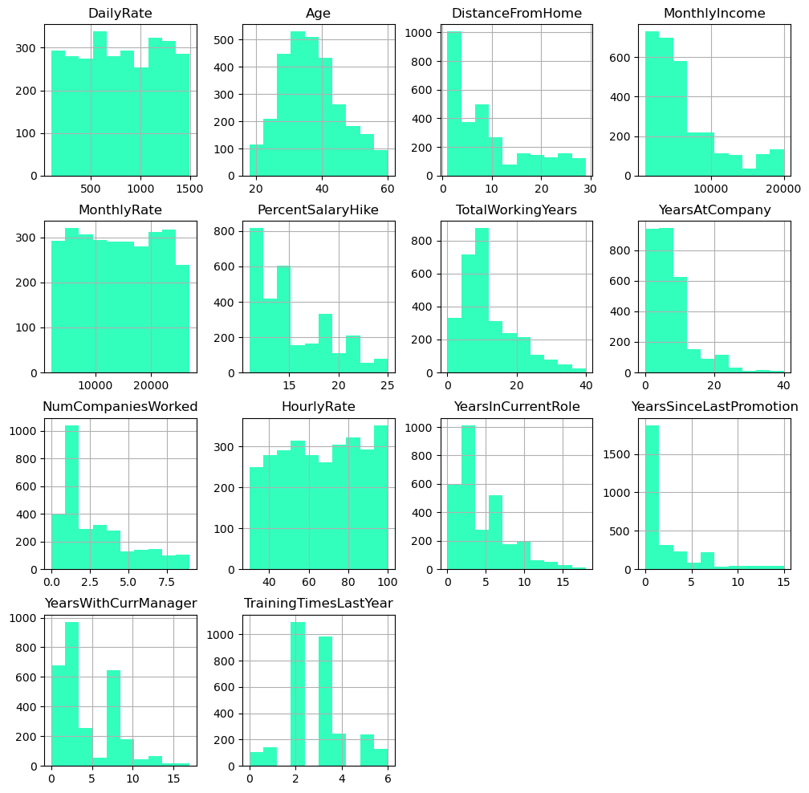

```python
#Ahora veremos la distribución de los datos. Crearemos histogramas
df[num_cols].hist(figsize=(12,12), color='#33FFBD')
plt.show()
```

**Observaciones:**

- La distribución de la edad de los colaboradores se parece a una distribución normal. Donde la mayoria esta entre los 25 y 50.
- La mayoria de los colaboradores viven cerca de la casa matriz y cada vez va bajando mas la gente en relacion a la distancia.
- Los ingresos mensuales y el número total de años de trabajo están sesgados a la derecha, lo que indica que la mayoría de los trabajadores ocupan puestos de nivel inicial o medio en la empresa.
- El porcentaje de aumento salarial está desviado hacia la derecha, lo que significa que la mayoría de los empleados reciben un porcentaje de aumento salarial más bajo.
- Existe una buena proporcion en YearsAtCompany respecto a los colaboradores que llevan mas de 10 años. Lo que demuestra que hay varias personas leales a la compañia.
- La distribución de la variable YearsSinceLastPromotion indica que algunos empleados no han recibido un ascenso en 10-15 años y siguen trabajando en la empresa. Se supone que estos empleados tienen una gran experiencia laboral y ocupan puestos de alta dirección, como cofundadores, empleados de la C-suite, etc (pero abria que indagar estos perfiles).

**ANALISIS A LAS COLUMNAS CATEGORICAS Y VER QUE SACAMOS DE AHÍ**

Con esto podremos ver el porcentaje de las categorias y cuantas existen por "opcion".

```python
for i in cat_cols:
    print(df[i].value_counts(normalize = True))
    print('*'*40)
```

```
No     0.838776
Yes    0.161224
Name: Attrition, dtype: float64
No     0.717007
Yes    0.282993
Name: OverTime, dtype: float64
Travel_Rarely        0.709524
Travel_Frequently    0.188435
Non-Travel           0.102041
Name: BusinessTravel, dtype: float64
Technology Department    0.653741
Business Department      0.303401
Human Resources          0.042857
Name: Department, dtype: float64
3    0.389116
4    0.270748
2    0.191837
1    0.115646
5    0.032653
Name: Education, dtype: float64
Programming         0.412245
Business            0.315646
Marketing           0.108163
Technical Degree    0.089796
Other               0.055782
Human Resources     0.018367
Name: EducationField, dtype: float64
4    0.312245
3    0.300680
1    0.196599
2    0.190476
Name: JobSatisfaction, dtype: float64
3    0.308163
4    0.303401
2    0.195238
1    0.193197
Name: EnvironmentSatisfaction, dtype: float64
3    0.607483
2    0.234014
4    0.104082
```

[output cut: 31 more lines]

```
Research Director         0.054422
Human Resources           0.035374
Name: JobRole, dtype: float64
Married     0.457823
Single      0.319728
Divorced    0.222449
Name: MaritalStatus, dtype: float64
3    0.312245
4    0.293878
2    0.206122
1    0.187755
Name: RelationshipSatisfaction, dtype: float64
Yes    0.727551
No     0.272449
Name: Gamers, dtype: float64
```

**Observaciones:**

- **La tasa de bajas de colaboradores es del 16%.**
- Alrededor de **28% de los trabajadores trabajan horas extras**. Un gran numero que influye en el balance de calidad de vida personal-profesional (factor de estres).
- Aproximadamente un **73% de los colaboradores vienen del mundo de la programación y business**. Y el 65% de los colaboradores trabajan en el **departamento de tecnología**.
- Cerca del **40% de los trabajadores evaluan su satisfacción laboral o ambiente laboral como baja o media**. Lo cual es un gran porcentaje de la plantilla.
- 19% de los coolaboradores viaja frecuentemente por el trabajo y 71% de los trabajadores rara vez.
- Mas del 30% de los empleados muestran una implicancia baja o media. Y mas del 80% de los empleados no tiene stockoptions o tiene muy pocas.
- El **73% de los colaboradores de RiotGames tiene relación con el mundo gamers.** Lo cual podría implicar relación con el producto y cultura de la organización.
- **Ninguno de los empleados a recibido una puntuación menor a 3 (excelente) respecto a su evaluación de desempeño (rendimiento)**. El 85% dfe sus colaboradores es evaluado 3 (excelente) y el resto 4 (sobre lo esperado). Dos escenarios:
  - Los colaboradores de Riot Games son increiblemente buenos.
  - El proceso de evaluación es indulgente. Y falta capacitar a la organizacion y lideres de como generar una correcta evaluación de desempeño.

# MixUp (Analisis columnas categoricas) / Multivariate Analysis

**Ahora analizaremos el relacion entre la tasa de abandono (attrition) con todas las otras variables categoricas.**

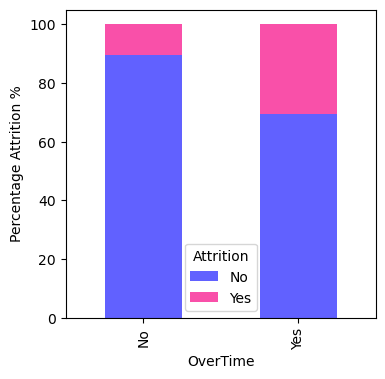

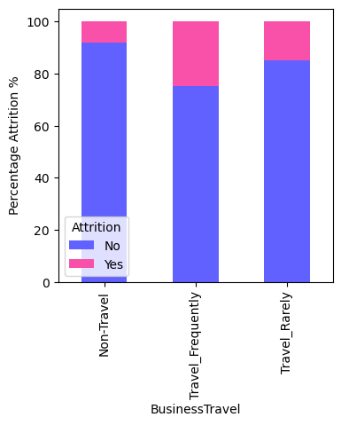

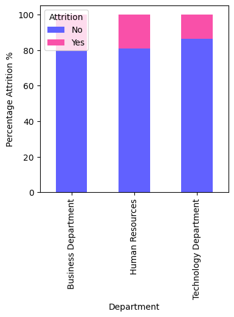

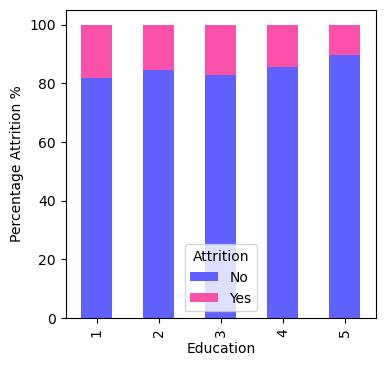

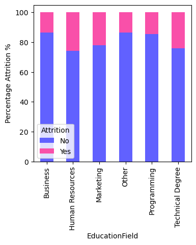

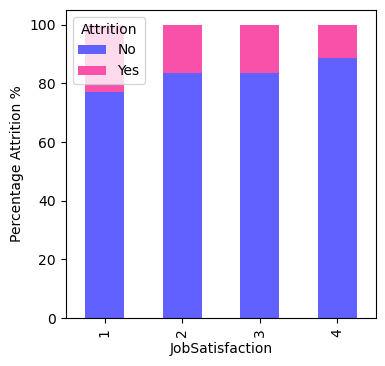

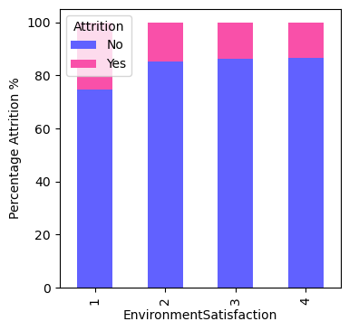

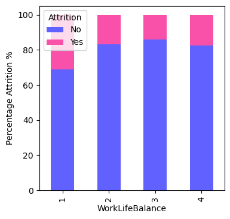

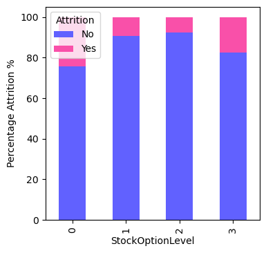

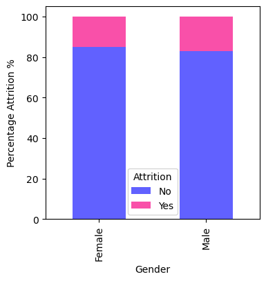

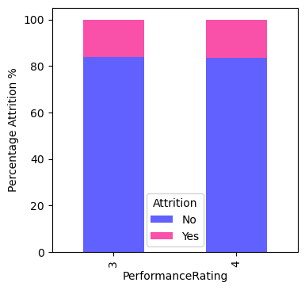

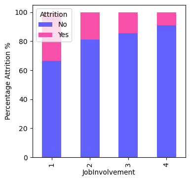

[5 more figures not shown]

```python
for i in cat_cols:
    if i !='Attrition':
        (pd.crosstab(df[i], df['Attrition'], normalize ='index')*100).plot(kind='bar', figsize=(4,4), stacked= True, color =['#6161FF','#f950a9'])
        plt.ylabel('Percentage Attrition %')
```

**Observaciones:**

- **Los trabajadores que hacen horas extra tienen un 30% más de probabilidad de abandono**. Lo cual es alto si se compara con el 10% de las personas que no tienen overtime.
- Como se comento antes, **la mayoria trabaja en el departamento de tecnología y es este mismo departamento con el menor indice de rotación**. La probabilidad de que se produzcan bajas es del ~15%.
- **Los cargos HR, Technical degree y Marketin son los que muestran un mayor indice de rotación del personal**. Se podria hipotetizar que se prioriza la retención de cargos que generan mas ingreso a la compañia y se descuidan los cargos que generan un mayor "costo" a la organización. Ya que los devs y los de business son los que menos rotación tienen y a la vez son escenciales para desarrollar y crear los productos.
- Se demuestra un increible correlación entre el grado de implicancia y el nivel de bajas de colaboradores. Donde **entre menos implicancia mayor es el porcentaje de rotación**. Donde los que estan en el nivel mas bajo de implicancia tienen un porcentaje del 35% de abandono. Seria interesante evaluar la relación entre implicancia y stock options, ver si existe una relación entre estos factores y el nivel de rotación. Ya que los que no tienen stock options son los que mas rotan, pero despues les continua los que más tienen stock options ¿A quien les estamos dando las stock options? ¿Tiene relación con el grado de implicancia? ¿Tener más StockOptions significa tener más implicancia con el trabajo?
- **Los empleados con un nivel de empleo inferior (entry level) también sufren más bajas**, y los empleados con un nivel de empleo de 1 tienen casi un 25% de probabilidades de abandonar. Puede tratarse de empleados jóvenes que tienden a explorar más opciones en las etapas iniciales de sus carreras.
- Que sean del **mundo gamers no demuestra implicancia en el nivel de rotación del personal**. No es un factor evidentemente fuerte en el nivel de retencion.

# MixUp (Analisis columnas numericas con Attrition)

Vamos a ver la relación entre la rotación y cada una de las variables numericas!

```python
df.groupby(['Attrition'])[num_cols].mean()
```

| Attrition | DailyRate | Age | DistanceFromHome | MonthlyIncome | MonthlyRate | PercentSalaryHike | TotalWorkingYears | YearsAtCompany | NumCompaniesWorked | HourlyRate | YearsInCurrentRole | YearsSinceLastPromotion | YearsWithCurrManager | TrainingTimesLastYear |
| --- | --- | --- | --- | --- | --- | --- | --- | --- | --- | --- | --- | --- | --- | --- |
| No | 812.504461 | 37.561233 | 8.915653 | 6832.739659 | 14265.779400 | 15.231144 | 11.862936 | 7.369019 | 2.645580 | 65.952149 | 4.484185 | 2.234388 | 4.367397 | 2.832928 |
| Yes | 750.362869 | 33.607595 | 10.632911 | 4787.092827 | 14559.308017 | 15.097046 | 8.244726 | 5.130802 | 2.940928 | 65.573840 | 2.902954 | 1.945148 | 2.852321 | 2.624473 |

**Observaciones:**

**ANALISIS DE RELACIÓN ENTRE LAS DISTINTAS VARIABLES NUMERICAS**

Vamos a ver como se correlacionan entre ellas. Donde haremos un mapa de calor y tendremos que identificar relaciones interesantes que puedan significar algo.

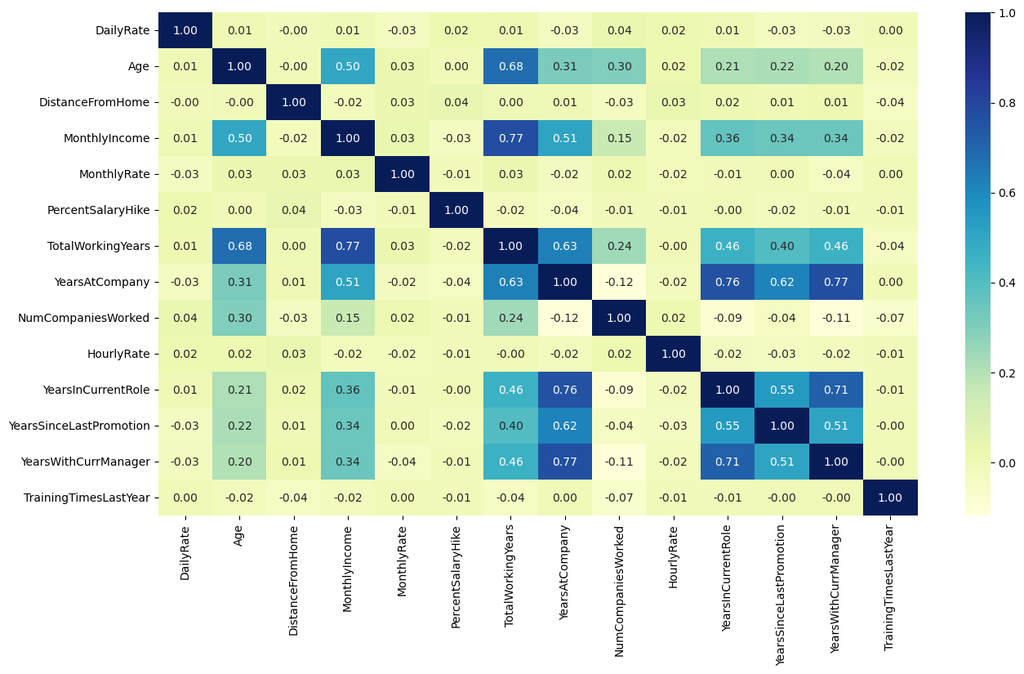

```python
plt.figure(figsize=(15,8))

sns.heatmap(df[num_cols].corr(), annot = True, fmt = '0.2f', cmap = 'YlGnBu')
```

**Observaciones:**

# Resumen del analsis de datos

**TERMINA LA PARTE I (ANALISIS DE LOS DATOS) Y COMIENZA PARTE II (ALGORTIMO PARA PREDECIR SALIDAS)**

# Modelo de Predicción de Salidas / Model Bouilding - Approach

**HEMOS ANALIZADO LA DATA, AHORA VAMOS A CONTRUIR EL MODELO PARA PREDECIR LAS SALIDAS DE LOS COLABORADORES DE RIOTGAMES**

De aqui en adelante el contenido es mas complicado de explicar, pero hare el mejor esfuerzo.

1. Preparar la dara para modelar.
2. Dividir los datos en conjuntos de entrenamientos y de test.
3. Construir el modelo con los datos de entrenamiento.
4. Ajustar el modelo.
5. Probar los datos en el conjunto de test.

# Preparando los datos para el modelo

Crando "dummy" variables para las variables categoricas. En general, es cambiar palabras por numeros.

```python
# Creando la lista de columna en donde debemos crear dummy variables.
to_get_dummies_for = ['BusinessTravel', 'Department', 'Education', 'EducationField', 'EnvironmentSatisfaction', 'Gender', 'JobInvolvement', 'JobLevel', 'JobRole', 'MaritalStatus','Gamers']

# Creando las dummy variables
df = pd.get_dummies(data = df, columns = to_get_dummies_for, drop_first = True)

# Mapeando overtime and attrition
dict_OverTime = {'Yes': 1, 'No': 0}
dict_attrition = {'Yes': 1, 'No': 0}

df['OverTime'] = df.OverTime.map(dict_OverTime)
df['Attrition'] = df.Attrition.map(dict_attrition)
```

```python
#Separando las variables independientes (X) entre las variables dependientes (Y)
Y = df.Attrition
X = df.drop(columns = ['Attrition'])
```

# Ahora bien.... Scaling the data

En este conjunto las variables independientes de este conjunto de datos tienen escalas diferentes. Cuando las características tienen escalas diferentes entre sí, existe la posibilidad de que se dé una mayor ponderación a las características que tienen una mayor magnitud, y dominarán sobre otras características cuyos cambios de magnitud pueden ser menores, pero cuyos cambios porcentuales pueden ser igual de significativos o incluso mayores. Esto afectará al rendimiento del algoritmo de aprendizaje automático.

Lo solucionaremos algo que se llama "Feature Scaling" (escalado de caracteristicas. En otras palabras, escalar el conjunto de datos para dar a cada variable transformada una escala comparable.

En este problema, utilizaremos el método Standard Scaler, que centra y escala el conjunto de datos utilizando el Z-Score.

Estandariza las características restando la media y escalándola para tener una varianza unitaria.

La puntuación estándar de la muestra x se calcula como

z = (x - u) / s

donde u es la media de las muestras de entrenamiento (cero) y s es la desviación estándar de las muestras de entrenamiento.

```python
# Scaling the data
sc = StandardScaler()

X_scaled = sc.fit_transform(X)

X_scaled = pd.DataFrame(X_scaled, columns = X.columns)
```

### Dividiendo la data en 70% train y 30% test sets

Para que el nivel, o mejor dicho porcentaje, de "Attrition" se mantenga equilibrado en ambas muestras. Ocuparemos un muestreo estratificado para garantizar tener la misma frecencia.

En palabras mas simples, queremos que en ambas muestras (train y test) tengamos un porcentaje de 16% attrition.

```python
# Splitting the data
x_train, x_test, y_train, y_test = train_test_split(X_scaled, Y, test_size = 0.3, random_state = 1, stratify = Y)
```

### Criterio de evaluación del modelo

**El modelo puede realizar dos tipos de predicciones erróneas:**

1. Predecir que un empleado abandonará cuando en realidad no lo hace.
2. Predecir que un empleado no se dará de baja cuando en realidad se da de baja.

**¿Qué caso es más importante?**

La respuesta correcta seia la numero dos. Predecir que el empleado no abandonara cuando en realidad se da de baja. Ya que esto se consideraria gran fallo para cualquier predictor de abandono de empleados y, por lo tanto, es el caso más importante de predicciones erróneas. ¿Cómo reducir esta pérdida, es decir, la necesida de reducir falsos negativos?

La empresa querría maximizar los Recall (recuperación); cuanto mayor sea, mayores serán las posibilidades de minimizar los falsos negativos. Por lo tanto, el objetivo debe ser aumentar la recuperación (minimizar los falsos negativos) o, en otras palabras, identificar muy bien los verdaderos positivos (es decir, la clase 1), de modo que la empresa pueda ofrecer incentivos para controlar la tasa de abandono, especialmente para los mejores. Esto ayudaría a optimizar el coste global del proyecto para retener a los mejores talentos.

Además, vamos a crear una función para calcular e imprimir el informe de clasificación y la matriz de confusión para que no tengamos que reescribir el mismo código repetidamente para cada modelo.

Recall: medida de la capacidad de un modelo de aprendizaje automático para identificar todos los casos relevantes de una clase determinada. En este caso, la clase positiva serian los empleados que abandonan las empresa y que el modelo identifica correctamente.

```python
def metrics_score(actual, predicted):

    print(classification_report(actual, predicted))

    cm = confusion_matrix(actual, predicted)

    plt.figure(figsize = (8, 5))

    sns.heatmap(cm, annot = True, fmt = '.2f', xticklabels = ['Not Attrite', 'Attrite'], yticklabels = ['Not Attrite', 'Attrite'])

    plt.ylabel('Actual')

    plt.xlabel('Predicted')

    plt.show()
```

### Creando el Modelo

**Vamos a crear 2 modelos diferentes:**

1. Logistic Regression (Regresión)
2. K-Nearest Neighbors (K-NN) (Vecinos próximos)

### Vamos por el primero... Modelo de regresion

```python
# Fitting the logistic regression model
lg = LogisticRegression()

lg.fit(x_train,y_train)
```

```
LogisticRegression()
```

**Revisemos el rendimiento de nuestro modelo**

```
              precision    recall  f1-score   support

           0       0.91      0.98      0.94      1726
           1       0.80      0.50      0.61       332

    accuracy                           0.90      2058
   macro avg       0.86      0.74      0.78      2058
weighted avg       0.89      0.90      0.89      2058
```

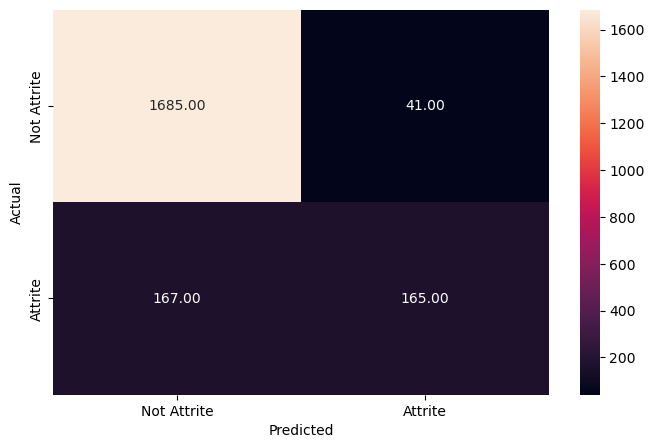

```python
# Evaluando el rendimiento en nuestro training data
y_pred_train = lg.predict(x_train)
metrics_score(y_train, y_pred_train)
```

```
              precision    recall  f1-score   support

           0       0.90      0.97      0.94       740
           1       0.75      0.46      0.57       142

    accuracy                           0.89       882
   macro avg       0.83      0.72      0.76       882
weighted avg       0.88      0.89      0.88       882
```

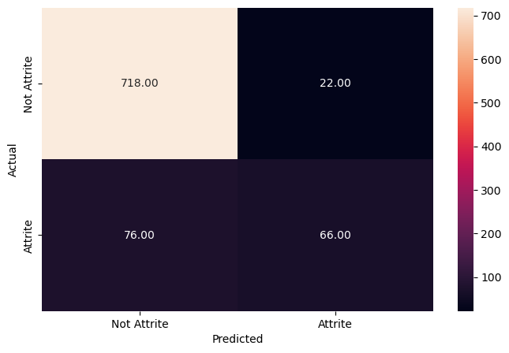

```python
# Evaluando el rendimiento en nuestro set data
y_pred_test = lg.predict(x_test)
metrics_score(y_test, y_pred_test)
```

**Observaciones:**

1. La primera observación es que el modelo tiene una precisión de alrededor del 90% tanto en el conjunto de datos de entrenamiento como en el de prueba. Esto significa que el modelo predice correctamente si un empleado abandonará o no la empresa en el 90% de los casos.
2. La segunda observación es que la recuperación de la clase 1 (empleados que abandonan la empresa) sólo ronda el 50% en los datos de entrenamiento y el 46% en los datos de prueba. La recuperación mide la eficacia del modelo a la hora de identificar a los empleados que corren el riesgo de abandonar la empresa. Una recuperación baja significa que el modelo no es bueno para identificar a los empleados que corren el riesgo de abandonar la empresa.
3. La tercera observación es que, como la recuperación es baja, el modelo no funcionará bien a la hora de distinguir a los empleados que tienen más probabilidades de abandonar la empresa. Esto significa que no ayudará a reducir la tasa de abandono.
4. La cuarta observación es que, como podemos ver en la matriz de confusión, este modelo no es bueno para identificar a los empleados que corren el riesgo de abandonar la empresa. Una matriz de confusión es una tabla que muestra el rendimiento de un modelo comparando sus predicciones con los resultados reales.

En resumen, aunque el modelo tiene una alta precisión, su baja recuperación significa que no es bueno para identificar a los empleados que corren el riesgo de abandonar la empresa. Esto significa que puede no ser eficaz para reducir las bajas.

**Comprobemos los coeficientes y averigüemos qué variables provocan el abandono y cuáles pueden ayudar a reducirlo.**

```python
# Visualizando el coeficiente de la regresion ligistica
cols = X.columns

coef_lg = lg.coef_

pd.DataFrame(coef_lg,columns = cols).T.sort_values(by = 0, ascending = False)
```

|  | 0 |
| --- | --- |
| OverTime | 0.954859 |
| BusinessTravel_Travel_Frequently | 0.720271 |
| MaritalStatus_Single | 0.623614 |
| YearsSinceLastPromotion | 0.551366 |
| YearsAtCompany | 0.534303 |
| NumCompaniesWorked | 0.496154 |
| BusinessTravel_Travel_Rarely | 0.446879 |
| DistanceFromHome | 0.386476 |
| JobRole_Human Resources | 0.386061 |
| EducationField_Technical Degree | 0.300268 |
| MaritalStatus_Married | 0.291952 |
| JobLevel_5 | 0.272820 |
| EducationField_Marketing | 0.219969 |
| Gender_Male | 0.166946 |
| Education_3 | 0.159227 |
| EducationField_Human Resources | 0.135193 |
| Education_2 | 0.133188 |
| Education_4 | 0.115034 |
| JobRole_Marketing Analyst | 0.096392 |
| Education_5 | 0.091082 |
| MonthlyRate | 0.058916 |
| EducationField_Programming | 0.052074 |
| HourlyRate | 0.047247 |
| EducationField_Other | 0.035985 |
| JobLevel_3 | -0.001782 |
| PerformanceRating | -0.034693 |
| Gamers_Yes | -0.035068 |
| Department_Technology Department | -0.048424 |
| JobRole_Manufacturing Director | -0.072903 |
| PercentSalaryHike | -0.074232 |
| JobRole_Developer | -0.074448 |
| DailyRate | -0.093721 |
| StockOptionLevel | -0.103986 |
| JobLevel_4 | -0.169284 |
| JobRole_Manager | -0.183561 |
| JobRole_Customer Experience | -0.186324 |
| WorkLifeBalance | -0.210766 |
| TrainingTimesLastYear | -0.242308 |
| Age | -0.271521 |
| RelationshipSatisfaction | -0.313403 |
| JobSatisfaction | -0.372680 |
| YearsWithCurrManager | -0.391109 |
| YearsInCurrentRole | -0.442057 |
| EnvironmentSatisfaction_2 | -0.445452 |
| JobInvolvement_2 | -0.480720 |
| TotalWorkingYears | -0.490906 |
| Department_Human Resources | -0.495187 |
| JobRole_Designer | -0.496220 |
| JobRole_Research Director | -0.498261 |
| EnvironmentSatisfaction_3 | -0.502891 |
| MonthlyIncome | -0.615774 |
| JobInvolvement_4 | -0.637248 |
| EnvironmentSatisfaction_4 | -0.652362 |
| JobLevel_2 | -0.727879 |
| JobInvolvement_3 | -0.744691 |

Aqui podemos observar que los que estan mas arriba y son de numeros positivos corresponden a los que afectan positivamente al % de salidas de colaboradores en RiotGames.

Por el contrario, los que se encuentran abajo, con numeros negativos, son los que afectan negativamente al nivel de salidas de colaboradores.

Los coeficientes del modelo de regresión logística nos dan el logaritmo de probabilidades, que es difícil de interpretar en el mundo real. Podemos convertir el logaritmo de probabilidades en probabilidades tomando su exponencial.

```python
odds = np.exp(lg.coef_[0]) # Transformando y encontrando las probabilidades

#Agregando las probabilidades de nuestra base de datos y ordenandolas
pd.DataFrame(odds, x_train.columns, columns = ['odds']).sort_values(by = 'odds', ascending = False)
```

|  | odds |
| --- | --- |
| OverTime | 2.598305 |
| BusinessTravel_Travel_Frequently | 2.054990 |
| MaritalStatus_Single | 1.865658 |
| YearsSinceLastPromotion | 1.735622 |
| YearsAtCompany | 1.706259 |
| NumCompaniesWorked | 1.642392 |
| BusinessTravel_Travel_Rarely | 1.563426 |
| DistanceFromHome | 1.471786 |
| JobRole_Human Resources | 1.471175 |
| EducationField_Technical Degree | 1.350220 |
| MaritalStatus_Married | 1.339039 |
| JobLevel_5 | 1.313663 |
| EducationField_Marketing | 1.246038 |
| Gender_Male | 1.181691 |
| Education_3 | 1.172605 |
| EducationField_Human Resources | 1.144757 |
| Education_2 | 1.142464 |
| Education_4 | 1.121911 |
| JobRole_Marketing Analyst | 1.101191 |
| Education_5 | 1.095359 |
| MonthlyRate | 1.060686 |
| EducationField_Programming | 1.053453 |
| HourlyRate | 1.048381 |
| EducationField_Other | 1.036640 |
| JobLevel_3 | 0.998220 |
| PerformanceRating | 0.965902 |
| Gamers_Yes | 0.965540 |
| Department_Technology Department | 0.952730 |
| JobRole_Manufacturing Director | 0.929691 |
| PercentSalaryHike | 0.928456 |
| JobRole_Developer | 0.928256 |
| DailyRate | 0.910536 |
| StockOptionLevel | 0.901238 |
| JobLevel_4 | 0.844269 |
| JobRole_Manager | 0.832301 |
| JobRole_Customer Experience | 0.830004 |
| WorkLifeBalance | 0.809963 |
| TrainingTimesLastYear | 0.784814 |
| Age | 0.762219 |
| RelationshipSatisfaction | 0.730955 |
| JobSatisfaction | 0.688886 |
| YearsWithCurrManager | 0.676306 |
| YearsInCurrentRole | 0.642713 |
| EnvironmentSatisfaction_2 | 0.640535 |
| JobInvolvement_2 | 0.618338 |
| TotalWorkingYears | 0.612071 |
| Department_Human Resources | 0.609457 |
| JobRole_Designer | 0.608828 |
| JobRole_Research Director | 0.607587 |
| EnvironmentSatisfaction_3 | 0.604780 |
| MonthlyIncome | 0.540223 |
| JobInvolvement_4 | 0.528745 |
| EnvironmentSatisfaction_4 | 0.520814 |
| JobLevel_2 | 0.482932 |
| JobInvolvement_3 | 0.474881 |

**Observaciones:**

- Las probabilidades de que un empleado que hace horas extras se desgaste son 2,6 veces superiores a las de uno que no hace horas extras, probablemente porque hacer horas extras no es sostenible durante mucho tiempo para ningún empleado, y puede provocar agotamiento e insatisfacción laboral.
- Las probabilidades de que un empleado que viaja con frecuencia se desgaste son el doble que las de un empleado que no viaja tan a menudo.
- Las probabilidades de que los empleados solteros abandonen el trabajo son aproximadamente 1,85 veces (un 85% más altas) que las de un empleado con otro estado civil.

**Curva de precisión/recuperación de la regresión logística**

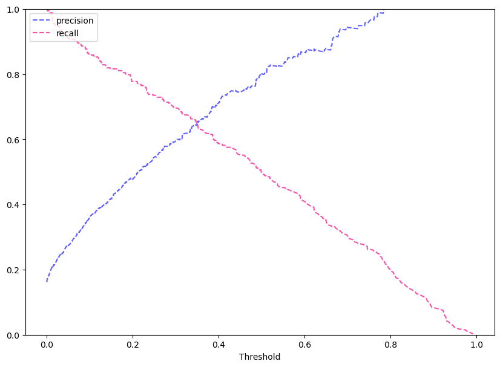

```python
y_scores_lg = lg.predict_proba(x_train) # predict_proba nos da la probabilidad de cada observacion belonging to each class


precisions_lg, recalls_lg, thresholds_lg = precision_recall_curve(y_train, y_scores_lg[:, 1])

# Plot values of precisions, recalls, and thresholds
plt.figure(figsize = (10, 7))

plt.plot(thresholds_lg, precisions_lg[:-1], 'b--', label = 'precision', color = '#6161ff')

plt.plot(thresholds_lg, recalls_lg[:-1], 'g--', label = 'recall', color = '#f950a9')

plt.xlabel('Threshold')

plt.legend(loc = 'upper left')

plt.ylim([0, 1])

plt.show()
```

**Observación:**

- Podemos ver que la precisión y el recuerdo están equilibrados para un umbral de alrededor de 0,35.
- El treshold determina el punto en el que el modelo clasifica una observación como positiva o negativa. Al ajustar este valor, puede controlar el equilibrio entre precisión y recuperación. Un umbral más bajo dará lugar a un mayor número de predicciones positivas, lo que aumentará la recuperación pero reducirá potencialmente la precisión. Un umbral más alto dará lugar a menos predicciones positivas, lo que aumentará la precisión pero podría reducir la recuperación.
- En este caso, la observación indica que cuando el umbral se fija en torno a 0,35, los valores de precisión y recuperación (Recall) se equilibran. Esto significa que, con este valor de umbral, el modelo es capaz de identificar correctamente una buena proporción de los casos positivos reales, al tiempo que mantiene un alto nivel de precisión en sus predicciones positivas.

**Averigüemos el rendimiento del modelo en este umbral.**

```
              precision    recall  f1-score   support

           0       0.93      0.93      0.93      1726
           1       0.65      0.64      0.65       332

    accuracy                           0.89      2058
   macro avg       0.79      0.79      0.79      2058
weighted avg       0.89      0.89      0.89      2058
```

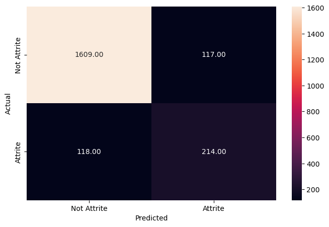

```python
optimal_threshold1 = .35

y_pred_train = lg.predict_proba(x_train)

metrics_score(y_train, y_pred_train[:, 1] > optimal_threshold1)
```

Observaciones:

- El rendimiento del modelo ha mejorado. La recuperación ha aumentado significativamente para la clase 1.

Comprobemos el rendimiento con los datos de prueba (set data).

```
              precision    recall  f1-score   support

           0       0.93      0.92      0.92       740
           1       0.60      0.62      0.61       142

    accuracy                           0.87       882
   macro avg       0.76      0.77      0.77       882
weighted avg       0.87      0.87      0.87       882
```

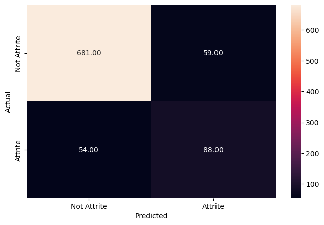

```python
optimal_threshold1 = .35

y_pred_test = lg.predict_proba(x_test)

metrics_score(y_test, y_pred_test[:, 1] > optimal_threshold1)
```

**Observaciones:**

# K-Nearest Neighbors (K-NN)

K-NN utiliza características de los datos de entrenamiento para predecir los valores de nuevos puntos de datos, lo que significa que al nuevo punto de datos se le asignará un valor basado en lo similar que es a los puntos de datos del conjunto de entrenamiento.

¿Que debemos hacer?

1. Seleccionar K
2. Calcular la distancia (Euclídea, Manhattan, etc.)
3. Encontrar los K vecinos más cercanos
4. Votar por mayoría las etiquetas

La "K" en el algoritmo K-NN es el número de vecinos más cercanos entre los que queremos votar. Generalmente, K es un número impar cuando el número de clases es par, para obtener un voto mayoritario. Supongamos que K=3. En ese caso, haremos un círculo con el nuevo punto de datos como centro tan grande como encerrar sólo los tres puntos de datos más cercanos en el plano.

**Pero antes de construir realmente el modelo, necesitamos identificar el valor de K que se utilizará en K-NN. Para ello realizaremos los siguientes pasos.**

```python
knn = KNeighborsClassifier()

# We select the optimal value of K for which the error rate is the least in the validation data
# Let us loop over a few values of K to determine the optimal value of K

train_error = []

test_error = []

knn_many_split = {}

error_df_knn = pd.DataFrame()

features = X.columns

for k in range(1, 15):
    train_error = []

    test_error = []

    lista = []

    knn = KNeighborsClassifier(n_neighbors = k)

    for i in range(30):
        x_train_new, x_val, y_train_new, y_val = train_test_split(x_train, y_train, test_size = 0.20)

        # Fitting K-NN on the training data
        knn.fit(x_train_new, y_train_new)

        # Calculating error on the training data and the validation data
        train_error.append(1 - knn.score(x_train_new, y_train_new))

        test_error.append(1 - knn.score(x_val, y_val))

    lista.append(sum(train_error)/len(train_error))

    lista.append(sum(test_error)/len(test_error))

    knn_many_split[k] = lista

knn_many_split
```

```
{1: [0.0, 0.09555016181229771],
 2: [0.05516403402187121, 0.14579288025889972],
 3: [0.05838396111786149, 0.15800970873786416],
 4: [0.11814499797488862, 0.15210355987055021],
 5: [0.109437019036047, 0.1519417475728156],
 6: [0.13063993519643577, 0.15056634304207123],
 7: [0.1228230052652896, 0.15307443365695797],
 8: [0.13681652490887, 0.15420711974110032],
 9: [0.13140947752126367, 0.1545307443365696],
 10: [0.1445727014985824, 0.15024271844660203],
 11: [0.13997569866342646, 0.15064724919093855],
 12: [0.14746861077359255, 0.15574433656957934],
 13: [0.14400567031186715, 0.14595469255663435],
 14: [0.14868367760226814, 0.15485436893203888]}
```

# PROYECTO EN PROCESO. TODAVÍA NO FINALIZADO.